# White Rose DTP - Analytics 2

Module Coordinator Mark Dunning

# Workshop Overview

High-throughput sequencing is now established as a standard technique for many functional genomics studies; allowing the researcher to compare and contrast the transcriptomes of many individuals to obtain biological insight. A high-volume of data are generated from these experimental techniques and thus require robust and reproducible tools to be employed in the analysis.

In this workshop, you will be learning how to analyse RNA-seq count data, using R. This will include reading the data into R, quality control and performing differential expression analysis and gene set testing, with a focus on the well-respected DESEq2 analysis workflow. You will learn how to generate common plots for analysis and visualisation of gene expression data, such as boxplots and heatmaps.

Although we will use RNA-seq data as a case study, the format of the data and methodologies will be highly applicable to other types of high-throughput omics data.

## Learning outcomes

After this workshop the successful learner will have a practical understanding of:

- Exploring RNA-seq count data and importing these data into R
- Normalisation strategies for RNA-seq counts
- Quality Assessment of counts
- Identifying outliers, batch effects and sample mix-ups
- Using the DESeq2 package to assess differential expression
- Construction and interpretation of common visualisations
- Using annotation packages to query biological databases
- Methodology behind gene set testing and enrichment analysis

## Teaching Style

- Pre-written *markdown* and compiled HTML files
  - links from the google doc
- Live sessions going through the markdown
  - including “breakout sessions” for exercise and questions
- Recordings made available
  - links from the google doc

# Learning objectives - Session 1

- Exploring count data and importing these data into R
- Normalisation strategies for RNA-seq counts
- Quality Assessment of counts
- Identifying outliers, batch effects and sample mix-ups

# Introduction

Measuring gene expression on a genome-wide scale has become common practice over the last two decades or so, with microarrays predominantly used pre-2008. With the advent of next generation sequencing technology in 2008, an increasing number of scientists use this technology to measure and understand changes in gene expression in often complex systems. As sequencing costs have decreased, using RNA-Seq to simultaneously measure the expression of tens of thousands of genes for multiple samples has never been easier. The cost of these experiments has now moved from generating the data to storing and analysing it.

There are many steps involved in analysing an RNA-Seq experiment.

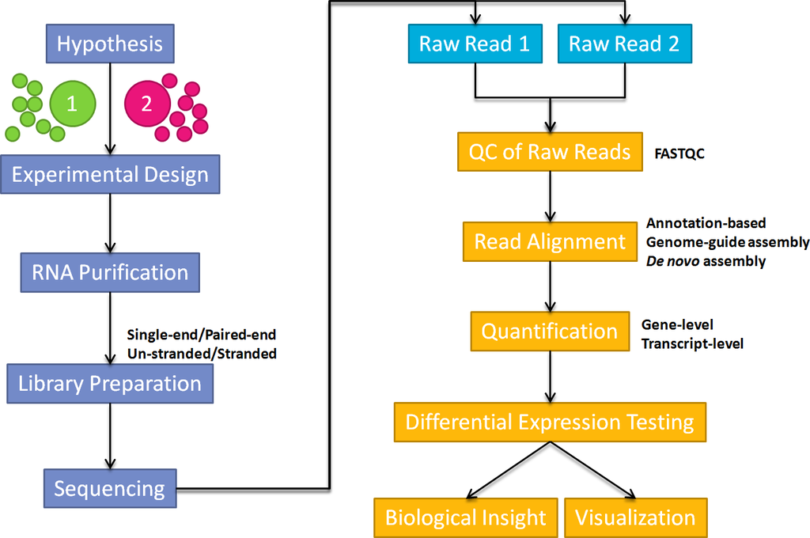

Workflow image from Ting-you Wang’s [RNA-seq data analysis page](https://databeauty.com/blog/tutorial/2016/09/13/RNA-seq-analysis.html)

Analysing an RNAseq experiment begins with sequencing reads. Traditionally, these are aligned to a reference genome, then the number of reads mapped to each gene can be counted. More modern approaches such as `salmon` quantify transcripts directly and do not require genome alignment to have taken place. Either approach results in a table of counts, which is what we perform statistical analyses on in R. While mapping and counting are important and necessary tasks, they are typically performed in languages other than R and so outside the scope of this course.

If you want to know more about genome alignment and command-line tools, feel free to check out our workshop on this topic in your own time

https://sbc.shef.ac.uk/training/command-line-2020-02-12/

In these sessions will be starting from the count data and getting straight into the analysis.

We will be following a workflow that uses the `DESeq2` package. An alternative and well-respected workflow is based on the [edgeR and limma packages](https://bioconductor.github.io/BiocWorkshops/rna-seq-analysis-is-easy-as-1-2-3-with-limma-glimma-and-edger.html).

### Mouse mammary gland dataset

The data for this tutorial comes from a Nature Cell Biology paper, [*EGF-mediated induction of Mcl-1 at the switch to lactation is essential for alveolar cell survival*](http://www.ncbi.nlm.nih.gov/pubmed/25730472).

This study examines the expression profiles of basal stem-cell enriched cells (B) and committed luminal cells (L) in the mammary gland of virgin, pregnant and lactating mice. Six groups are present, with one for each combination of cell type and mouse status. Each group contains two biological replicates.

The sequencing reads for this experiment were uploaded to the [Sequencing Read Archive (SRA)](https://www.ncbi.nlm.nih.gov/sra?term=SRP045534) and processed using `salmon`. However, the workflow we will describe can be applied to other sources of count data.

# Obtaining the metadata

We refer to *metadata* as the data that describes the biological and technical characteristics of the samples we have sequenced. Examples of variables recorded in the metadata might include.

- tumour / normal status
- cell line
- age
- gender
- date of collection
- litter

We include the sample groups that we want to compare, and any potential *confounding factors* that we might need to address as part of our quality assessment. The metadata is stored in a spreadsheet and typically entered by-hand. When creating such data we should be mindful of some best-practice guidelines that will make our data easier to read into R.

See here for a round-up of common errors to be avoiding when creating spreadsheets [Data Carpentry lesson on spreadsheet errors](https://datacarpentry.org/spreadsheet-ecology-lesson/02-common-mistakes/index.html)

The `sampleInfo.txt` in the `meta_data` folder contains basic information about the samples that we will need for the analysis today. This includes the ID for the sample from SRA, an ID assigned by the researcher, and the cell type and developmental stage for each sample.

```r
# Read the sample information into R
sampleinfo <- read.delim("meta_data/sampleInfo.txt")
View(sampleinfo)
rownames(sampleinfo) <- sampleinfo$run
sampleinfo
```

|  | run | Name | CellType | Status |
| --- | --- | --- | --- | --- |
| SRR1552444 | SRR1552444 | MCL1-LA | basal | virgin |
| SRR1552445 | SRR1552445 | MCL1-LB | luminal | virgin |
| SRR1552446 | SRR1552446 | MCL1-LC | Luminal | pregnancy |
| SRR1552447 | SRR1552447 | MCL1-LD | Luminal | pregnancy |
| SRR1552448 | SRR1552448 | MCL1-LE | luminal | lactation |
| SRR1552449 | SRR1552449 | MCL1-LF | luminal | lactation |
| SRR1552450 | SRR1552450 | MCL1-DG | basal | virgin |
| SRR1552451 | SRR1552451 | MCL1-DH | luminal | virgin |
| SRR1552452 | SRR1552452 | MCL1-DI | basal | pregnancy |
| SRR1552453 | SRR1552453 | MCL1-DJ | basal | pregnancy |

[output cut: 2 more lines]

# Reading in the count data

Eventually we will be using the DESeq2 Bioconductor package for differential expression analysis. The precise method of importing your count data into DESeq2 depends on the workflow used to generate the counts. The [DESeq2 vignette](https://bioconductor.org/packages/release/bioc/vignettes/DESeq2/inst/doc/DESeq2.html#input-data) gives many different use-cases. For instance, if you have your counts in a single file (e.g. if following our Galaxy tutorials) you can follow [this example](https://bioconductor.org/packages/release/bioc/vignettes/DESeq2/inst/doc/DESeq2.html#countmat)

### Overview

We are going to use the [`tximport`](http://dx.doi.org/10.12688/f1000research.7563.1) package to import our count data into R and collapse the data to the *gene level*. This requires us to run a function in the following form:-

```r
txi <- tximport(files=..., type="salmon", tx2gene=...)
```

So we will need to define the files that we want to import and a transcript mapping data frame. The transcript mapping takes the form:-

```
 | TXNAME | GENEID
1| ENST00000456328.2 |  ENSG00000223972.5
2| ENST00000450305.2 | ENSG00000223972.5
3| ENST00000473358.1 | ENSG00000243485.5
4| ENST00000469289.1 | ENSG00000243485.5
5| ENST00000607096.1 | ENSG00000284332.1
6| ENST00000606857.1 | ENSG00000268020.3
```

`tximport` is able to import counts produced by different software, and different workflows are described for each in the [tximport vignette](https://bioconductor.org/packages/devel/bioc/vignettes/tximport/inst/doc/tximport.html).

## Identifying the files

The samples from this study have been *quantified* using `salmon`, which is beyond the scope of this workshop. Note that the salmon analysis produced many other files (e.g. log files), but we will only need the `quant.sf.gz` files for analysis.

The function we are going to use to import the salmon files requires a `vector` comprising the paths to the files that are to be imported. To construct such a vector we can use the following code chunk. We can name each item in the vector according to the directory name. These names will be used eventually to name the columns of our count matrices.

```r
dirs <- list.files("salmon_quant/")
quant_files <- list.files("salmon_quant/",pattern="quant.sf.gz",recursive = TRUE,full.names = TRUE)
names(quant_files) <- dirs
quant_files
```

```
                            SRR1552444
"salmon_quant//SRR1552444/quant.sf.gz"
                            SRR1552445
"salmon_quant//SRR1552445/quant.sf.gz"
                            SRR1552446
"salmon_quant//SRR1552446/quant.sf.gz"
                            SRR1552447
"salmon_quant//SRR1552447/quant.sf.gz"
                            SRR1552448
"salmon_quant//SRR1552448/quant.sf.gz"
                            SRR1552449
"salmon_quant//SRR1552449/quant.sf.gz"
                            SRR1552450
"salmon_quant//SRR1552450/quant.sf.gz"
                            SRR1552451
"salmon_quant//SRR1552451/quant.sf.gz"
                            SRR1552452
"salmon_quant//SRR1552452/quant.sf.gz"
                            SRR1552453
"salmon_quant//SRR1552453/quant.sf.gz"
                            SRR1552454
"salmon_quant//SRR1552454/quant.sf.gz"
                            SRR1552455
"salmon_quant//SRR1552455/quant.sf.gz"
```

### Inspecting the salmon output

The quant files are simple tab-delimited files that tabulate the counting results for each *transcript* in our chosen organism. Although we will use a specialised Bioconductor package (`tximport`) to import the counts for entire dataset into R, we can inspect the first of the files using the standard `read_tsv` function from the `readr` package.

```r
library(readr)
quants <- read_tsv(quant_files[1])
head(quants)
```

| Name | Length | EffectiveLength | TPM | NumReads |
| --- | --- | --- | --- | --- |
| ENSMUST00000177564.1 | 16 | 3 | 0 | 0 |
| ENSMUST00000196221.1 | 9 | 2 | 0 | 0 |
| ENSMUST00000179664.1 | 11 | 2 | 0 | 0 |
| ENSMUST00000178537.1 | 12 | 3 | 0 | 0 |
| ENSMUST00000178862.1 | 14 | 3 | 0 | 0 |
| ENSMUST00000179520.1 | 11 | 2 | 0 | 0 |

```r
dim(quants)
```

```
[1] 109898      5
```

```r
tx2gene <- read_csv("tx2gene.csv")
head(tx2gene)
```

| TXNAME | GENEID |
| --- | --- |
| ENSMUST00000193812 | ENSMUSG00000102693 |
| ENSMUST00000082908 | ENSMUSG00000064842 |
| ENSMUST00000192857 | ENSMUSG00000102851 |
| ENSMUST00000161581 | ENSMUSG00000089699 |
| ENSMUST00000192183 | ENSMUSG00000103147 |
| ENSMUST00000193244 | ENSMUSG00000102348 |

We can import our dataset with the `tximport` package. The `ignoreTxVersion` argument needs to be set to `TRUE`; you might have noticed that the transcript names in the quant files have a version number at the end `e.g. .1`, so won’t match the transcript names in the `tx2gene` table.

```r
library(tximport)
txi <- tximport(quant_files,type="salmon",tx2gene = tx2gene,ignoreTxVersion = TRUE)
```

```
reading in files with read_tsv
1 2 3 4 5 6 7 8 9 10 11 12
transcripts missing from tx2gene: 147
summarizing abundance
summarizing counts
summarizing length
```

The resulting object is a “*list*” structure in R which contains a number of components that we can access using a `$` operator

The raw counts can be found using `txi$counts`

```r
head(txi$counts)
```

```
                   SRR1552444
ENSMUSG00000000001   5443.000
ENSMUSG00000000003      0.000
ENSMUSG00000000028    259.000
ENSMUSG00000000037     66.000
ENSMUSG00000000049      2.000
ENSMUSG00000000056    266.253
                   SRR1552445
ENSMUSG00000000001   6085.000
ENSMUSG00000000003      0.000
ENSMUSG00000000028    329.753
ENSMUSG00000000037     97.999
ENSMUSG00000000049      3.000
ENSMUSG00000000056    326.000
                   SRR1552446
ENSMUSG00000000001   5773.000
ENSMUSG00000000003      0.000
ENSMUSG00000000028    267.000
ENSMUSG00000000037     65.999
ENSMUSG00000000049      0.000
ENSMUSG00000000056    589.000
                   SRR1552447
ENSMUSG00000000001       5166
ENSMUSG00000000003          0
ENSMUSG00000000028        102
ENSMUSG00000000037         42
ENSMUSG00000000049          0
ENSMUSG00000000056        464
                   SRR1552448
ENSMUSG00000000001       2191
ENSMUSG00000000003          0
ENSMUSG00000000028        231
ENSMUSG00000000037         24
ENSMUSG00000000049          0
ENSMUSG00000000056        402
                   SRR1552449
ENSMUSG00000000001       2189
ENSMUSG00000000003          0
ENSMUSG00000000028        206
ENSMUSG00000000037         21
```

[output cut: 29 more lines]

```
ENSMUSG00000000056        230
                   SRR1552454
ENSMUSG00000000001       3550
ENSMUSG00000000003          0
ENSMUSG00000000028         44
ENSMUSG00000000037        238
ENSMUSG00000000049          3
ENSMUSG00000000056        441
                   SRR1552455
ENSMUSG00000000001   2800.000
ENSMUSG00000000003      0.000
ENSMUSG00000000028     63.000
ENSMUSG00000000037    192.000
ENSMUSG00000000049      2.000
ENSMUSG00000000056    398.001
```

# Quality control of the imported counts

We will be using the `DESeq2` library to analyse this dataset. Along with the counts and metadata, a *design* for the experiment also needs to be specified. This will define how the differential expression analysis is carried out, but can be changed at a later stage so for now we will use `CellType` as our factor of interest.

```r
library(DESeq2)
dds <- DESeqDataSetFromTximport(txi,
                                colData = sampleinfo,
                                design <- ~CellType)
```

```
some variables in design formula are characters, converting to factors
```

```r
dds
```

```
class: DESeqDataSet
dim: 34452 12
metadata(1): version
assays(2): counts avgTxLength
rownames(34452):
  ENSMUSG00000000001
  ENSMUSG00000000003 ...
  ENSMUSG00000115847
  ENSMUSG00000115848
rowData names(0):
colnames(12): SRR1552444
  SRR1552445 ... SRR1552454
  SRR1552455
colData names(4): run Name
  CellType Status
```

The object contains all the counts along with the metadata for the experiment

```r
head(assay(dds))
```

```
                   SRR1552444
ENSMUSG00000000001       5443
ENSMUSG00000000003          0
ENSMUSG00000000028        259
ENSMUSG00000000037         66
ENSMUSG00000000049          2
ENSMUSG00000000056        266
                   SRR1552445
ENSMUSG00000000001       6085
ENSMUSG00000000003          0
ENSMUSG00000000028        330
ENSMUSG00000000037         98
ENSMUSG00000000049          3
ENSMUSG00000000056        326
                   SRR1552446
ENSMUSG00000000001       5773
ENSMUSG00000000003          0
ENSMUSG00000000028        267
ENSMUSG00000000037         66
ENSMUSG00000000049          0
ENSMUSG00000000056        589
                   SRR1552447
ENSMUSG00000000001       5166
ENSMUSG00000000003          0
ENSMUSG00000000028        102
ENSMUSG00000000037         42
ENSMUSG00000000049          0
ENSMUSG00000000056        464
                   SRR1552448
ENSMUSG00000000001       2191
ENSMUSG00000000003          0
ENSMUSG00000000028        231
ENSMUSG00000000037         24
ENSMUSG00000000049          0
ENSMUSG00000000056        402
                   SRR1552449
ENSMUSG00000000001       2189
ENSMUSG00000000003          0
ENSMUSG00000000028        206
ENSMUSG00000000037         21
```

[output cut: 29 more lines]

```
ENSMUSG00000000056        230
                   SRR1552454
ENSMUSG00000000001       3550
ENSMUSG00000000003          0
ENSMUSG00000000028         44
ENSMUSG00000000037        238
ENSMUSG00000000049          3
ENSMUSG00000000056        441
                   SRR1552455
ENSMUSG00000000001       2800
ENSMUSG00000000003          0
ENSMUSG00000000028         63
ENSMUSG00000000037        192
ENSMUSG00000000049          2
ENSMUSG00000000056        398
```

```r
colData(dds)
```

```
DataFrame with 12 rows and 4 columns
                   run        Name
           <character> <character>
SRR1552444  SRR1552444     MCL1-LA
SRR1552445  SRR1552445     MCL1-LB
SRR1552446  SRR1552446     MCL1-LC
SRR1552447  SRR1552447     MCL1-LD
SRR1552448  SRR1552448     MCL1-LE
...                ...         ...
SRR1552451  SRR1552451     MCL1-DH
SRR1552452  SRR1552452     MCL1-DI
SRR1552453  SRR1552453     MCL1-DJ
SRR1552454  SRR1552454     MCL1-DK
SRR1552455  SRR1552455     MCL1-DL
           CellType      Status
           <factor> <character>
SRR1552444  basal        virgin
SRR1552445  luminal      virgin
SRR1552446  Luminal   pregnancy
SRR1552447  Luminal   pregnancy
SRR1552448  luminal   lactation
...             ...         ...
SRR1552451  luminal      virgin
SRR1552452  basal     pregnancy
SRR1552453  basal     pregnancy
SRR1552454  basal     lactation
SRR1552455  basal     lactation
```

### Visualising library sizes

We can look at a few different plots to check that the data is good quality, and that the samples are behaving as we would expect. First, we can check how many reads we have for each sample in the `DESeqDataSet`. The counts themselves are accessed using the `assay` function; giving a matrix of counts. The sum of a particular column is therefore the total number of reads for that sample.

```r
sum(assay(dds)[,1])
```

```
[1] 24444863
```

A convenience function `colSums` exists for calculating the sum of each column in a matrix, returning a `vector` as a result.

```r
colSums(assay(dds))
```

```
SRR1552444 SRR1552445 SRR1552446
  24444863   25995520   26800109
SRR1552447 SRR1552448 SRR1552449
  26378758   29201722   29106858
SRR1552450 SRR1552451 SRR1552452
  27070438   25504036   27990146
SRR1552453 SRR1552454 SRR1552455
  26185840   24395121   22722335
```

# Exercise

- Use an appropriate function from `dplyr` to add a column containing the number of reads for each sample to the `sampleinfo` data frame.
- Produce a bar plot to show the Millions of reads for each sample

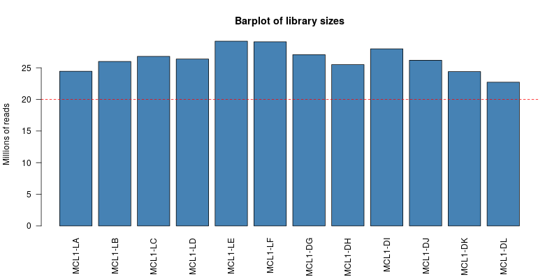

### Visualising count distributions

We typically use a `boxplot` to visualise difference the distributions of the columns of a numeric data frame. Applying the `boxplot` function to the raw counts from our dataset reveals something about the nature of the data; the distributions are dominated by a few genes with very large counts.

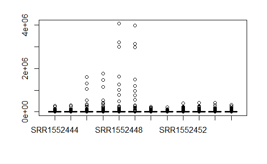

```r
boxplot(assay(dds))
```

We can use the `vst` or `rlog` function from `DESeq2`to compensate for the effect of different library sizes and put the data on the log$_2$ scale. The effect is to remove the dependence of the variance on the mean, particularly the high variance of the logarithm of count data when the mean is low. For more details see the [DESeq2 vignette](http://bioconductor.org/packages/devel/bioc/vignettes/DESeq2/inst/doc/DESeq2.html#count-data-transformations)

```r
# Get log2 counts
vsd <- vst(dds,blind=TRUE)
```

```
using 'avgTxLength' from assays(dds), correcting for library size
```

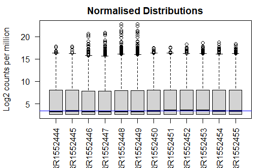

```r
# Check distributions of samples using boxplots
boxplot(assay(vsd), xlab="", ylab="Log2 counts per million",las=2,main="Normalised Distributions")
# Let's add a blue horizontal line that corresponds to the median logCPM
abline(h=median(assay(vsd)), col="blue")
```

## Principal components Analysis (PCA)

See here for a nice explanation of PCA https://www.youtube.com/watch?v=0Jp4gsfOLMs

The [(Principal Components Analysis) PCA](http://setosa.io/ev/principal-component-analysis/) plot, shows the samples in the 2D plane spanned by their first two principal components. A principle components analysis is an example of an unsupervised analysis, where we don’t need to specify the groups. If your experiment is well-controlled and has worked well, what we hope to see is that the greatest sources of variation in the data correspond to the treatments/groups we are interested in. It is also an incredibly useful tool for quality control and checking for outliers.

`DESeq2` has a convenient `plotPCA` function for making the PCA plot, which makes use of the `ggplot2` graphics package.

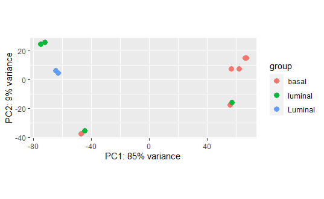

```r
plotPCA(vsd,intgroup="CellType")
```

# Exercise

- Is the `plotPCA` plot based on all genes in the dataset? How can we change how many genes are used for the PCA analysis? Does this significantly change the plot? (HINT: check the documentation for the `plotPCA` function.)
- Change the `intgroup` parameter so that both CellType and Status are used for grouping. (See the documentation again)
- Is there something strange going on with the samples?
- Identify the two samples that don’t appear to be in the right place.
- What other problems can you see with the metadata?

### Note about batch effects

In our unsupervised analysis we should see that the main source of variation is due to biological effects, and not technical variation such as when the libraries were sequenced. If we do observe high technical variation in our data, it is not a complete disaster provided that we have designed our experiment properly. In particular the [sva Bioconductor package](https://bioconductor.org/packages/release/bioc/vignettes/sva/inst/doc/sva.pdf) can correct for batch effects provided that representatives of the groups of interest appear in each batch. Alternatively, the batch or confounding factor may be incorporated into the differential expression analysis.

### Correcting the sample information

Hopefully we have spotted a potential sample swap in the dataset. The mislabeled samples are MCL1.DH, which is labeled as luminal but should be basal, and MCL1.LA, which is labeled as basal but should be luminal. Such errors are not uncommon when handling large numbers of samples and sometimes we need to go back to the lab books and verify that a swap has been made. *If there is no supporting evidence for a swap then it can be safer to exclude the samples*.

Furthermore, the person creating the sample sheet has been inconsistent about the way that values of `CellType` and `Status` have been entered into the metadata. Such errors can be annoying when labeling plots, but have more serious consequences when attempting to fit statistical models to the data.

```r
library(stringr)
library(dplyr)
sampleinfo %>%
mutate(CellType = str_to_lower(CellType)) %>%
mutate(Status = str_trim(Status)) %>%
mutate(CellType = ifelse(Name == "MCL1-DH","basal",CellType)) %>%
mutate(CellType= ifelse(Name == "MCL1-LA","luminal",CellType)) %>%
write.table(file="meta_data/sampleInfo_corrected.txt",sep="\t",row.names = FALSE)
```

# Exercise for next time

- Re-create the `DESeqDataset` object to include the corrected sample information
- Re-run the plotPCA function on the new data and verify that the sample groups now look correct
- Make an R notebook to document your analysis
- We used “base R” to make a boxplot of the variance-stabilised counts for convenience. To keep with the tidyverse theme, try to make the plot using `ggplot2`. For the first few steps you will need to make a data frame with an ID column (see below). Then investigate the `tidyr` package to transform the data into a shape that `ggplot2` is happy with.

```r
assay(vsd) %>%
  data.frame %>%
  tibble::rownames_to_column("Gene")
```

| Gene | SRR1552444 | SRR1552445 | SRR1552446 | SRR1552447 | SRR1552448 | SRR1552449 | SRR1552450 | SRR1552451 | SRR1552452 | SRR1552453 | SRR1552454 | SRR1552455 |
| --- | --- | --- | --- | --- | --- | --- | --- | --- | --- | --- | --- | --- |
| ENSMUSG00000000001 | 12.057637 | 12.151628 | 12.464915 | 12.454322 | 11.915857 | 11.884294 | 11.725228 | 11.858293 | 11.882722 | 11.896504 | 11.827621 | 11.512390 |
| ENSMUSG00000000003 | 2.599364 | 2.599364 | 2.599364 | 2.599364 | 2.599364 | 2.599364 | 2.599364 | 2.599364 | 2.599364 | 2.599364 | 2.599364 | 2.599364 |
| ENSMUSG00000000028 | 7.694663 | 7.999138 | 8.158868 | 6.930031 | 8.584718 | 8.546887 | 7.938876 | 7.845036 | 7.415003 | 7.492733 | 5.832853 | 6.189929 |
| ENSMUSG00000000037 | 5.365573 | 6.667906 | 6.136889 | 6.267275 | 6.104506 | 5.204293 | 7.104173 | 7.685869 | 7.972394 | 7.663198 | 7.175062 | 8.011156 |
| ENSMUSG00000000049 | 4.003697 | 3.219840 | 2.599364 | 2.599364 | 2.599364 | 2.599364 | 3.778865 | 3.526780 | 2.976944 | 3.153631 | 4.229933 | 3.196733 |
| ENSMUSG00000000056 | 7.724546 | 8.189532 | 9.239598 | 9.074485 | 8.721359 | 9.386525 | 9.352951 | 8.810908 | 8.762465 | 7.711687 | 8.864432 | 8.776353 |
| ENSMUSG00000000058 | 10.984773 | 10.968067 | 10.222070 | 10.677574 | 13.107666 | 12.847987 | 11.201242 | 11.141257 | 11.657792 | 11.754267 | 12.216316 | 12.226609 |
| ENSMUSG00000000078 | 15.144951 | 15.281191 | 15.472057 | 15.636073 | 15.597494 | 15.587640 | 14.072386 | 14.058882 | 14.391600 | 14.502333 | 15.259394 | 15.373414 |
| ENSMUSG00000000085 | 8.937849 | 9.238165 | 7.533109 | 8.326216 | 7.698888 | 7.058816 | 9.797180 | 10.229217 | 9.709947 | 9.356620 | 10.533188 | 10.537979 |
| ENSMUSG00000000088 | 11.173865 | 10.966246 | 11.726341 | 11.685571 | 12.445467 | 12.444287 | 10.336025 | 10.324671 | 10.683331 | 10.618245 | 10.098284 | 9.927984 |

[output cut: 990 more lines]

# Appendix

### Defining the transcript mapping

In order for `tximport` to give *gene-level* counts, we need to supply a data frame that can be used to associate each transcript name with a gene identifier. **It is important to use a transcript file that corresponds to the name genome build as the file used to count the transcripts**.

We can check if the `gtf` file exists in the directory we expect by running the `file.exists` function; returning `TRUE` or `FALSE`

```r
gtf_file <- "Mus_musculus.GRCm38.91.chr.gtf.gz"
file.exists(gtf_file)
```

```
[1] FALSE
```

If required, we can download from the Ensembl FTP site.

```r
download.file("ftp://ftp.ensembl.org/pub/release-91/gtf/mus_musculus/Mus_musculus.GRCm38.91.chr.gtf.gz",destfile = gtf_file)
```

### Note on analysing your own data

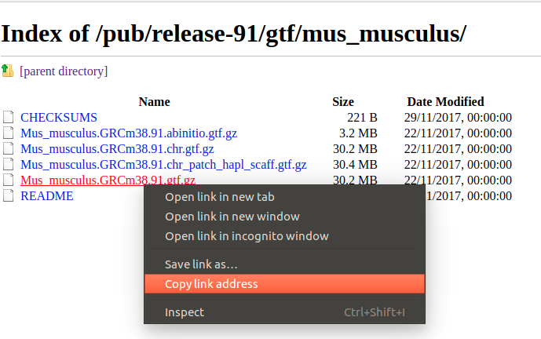

If analysing your own data, you will have to locate the gtf file on the Ensembl FTP site. If you enter `ftp://ftp.ensembl.org/pub/release-91/gtf` into a web browser you will be able to navigate the site and find your organism of interest. By right-clicking on the name of the gtf you will be able to copy the URL and then paste into RStudio.

```r
gtf_file <- "ensembl_ref/my_ref.gtf"
download.file(PASTE_LINK_FROM_ENSEMBL_HERE,destfile = gtf_file)
```

### Creating a transcript database

The Bioconducor website provides many pre-built transcript databases for some organisms (Human, Mouse, Rat etc) which provide transcript definitions and allow users to query the locations of particular genes, exons and other genomic features. You may find a pre-built package that already has the transcript locations required to create the transcript mapping file. Check out the annotation section of the Bioconductor website - http://bioconductor.org/packages/release/BiocViews.html#___AnnotationData and look for packages starting `TxDb...`

However, it is quite easy to build such a database if we have a `gtf` file using the `GenomicFeatures` infrastructure.

```r
## Could take a few minutes to run the makeTxDbFromGFF command
library(GenomicFeatures)
txdb <- makeTxDbFromGFF(gtf_file)
```

The database has a number of predefined “keys” and “columns” that have to be specified when creating a query

```r
keytypes(txdb)
```

```r
columns(txdb)
```

Sometimes we would want to query the positions for a limited set of selected genes (perhaps the results of a differential-expression analysis), but in this case we want the gene names that correspond to every transcript in the database. To get the names of all transcripts we can use the `keys` function. We then compose the query using the `select` function to return a data frame

```r
k <- keys(txdb, keytype="TXNAME")
tx_map <- select(txdb, keys = k, columns="GENEID", keytype = "TXNAME")
head(tx_map)
```

# Acknowledgement

**Original Authors: Belinda Phipson, Anna Trigos, Matt Ritchie, Maria Doyle, Harriet Dashnow, Charity Law**, **Stephane Ballereau, Oscar Rueda, Ashley Sawle** Based on the course [RNAseq analysis in R](http://combine-australia.github.io/2016-05-11-RNAseq/) delivered on May 11/12th 2016 and modified by Cancer Research Uk Cambridge Centre for the [Functional Genomics Autumn School 2017](https://bioinformatics-core-shared-training.github.io/cruk-autumn-school-2017/)